# Initial EDA Basic Outline

Sijie Wu

This is an outline for your Initial EDA. You can follow this outline, or you can modify it as you see fit. Do what works best for your project.

## Research Question

Is there a correlation between the popularity of manga and the ranking of their anime adaptations?

### Why is it interesting?

- Cross-Media Influence: Understanding the relationship between manga sales and anime rankings can provide insights into how success in one medium (print) translates to success in another (animation). This can be valuable for publishers, producers, and marketers.
- Consumer Behavior: It sheds light on consumer preferences and behaviors. Are popular manga titles more likely to have successful anime adaptations? This can help in predicting the success of future adaptations.
- Cultural Impact: The findings can contribute to the broader understanding of the impact of Japanese pop culture across different media platforms.
- Industry Insights: For those studying the anime and manga industry, it provides empirical data that can influence business strategies, such as investment in anime adaptations of popular manga.
- Fan Engagement: It could also be of interest to fans who might want to see their favorite manga adapted into anime and understand the factors that influence such decisions.

## Data Processing

#### Data Intake

Include R code and written explanation to import your **TWO** data sets.

### Origin and Purpose of Data

#### Anime Rank Dataset:

- Origin: This dataset was collected from kaggle.
- Purpose: It includes information about the highest-ranked anime, including scores, member counts, and rankings.

#### Best-Selling Manga Dataset:

- Origin: This dataset was collected from kaggle.
- Purpose: It lists the best-selling manga series, including approximate sales, number of volumes, and authors.

### Investigate and Explain Key Variables:

#### Top Anime Ranked Dataset:

- Title: Name of the anime.
- Rank: Position in the ranking.
- Score: Average score given by users.
- Members: Number of members who have interacted with the anime.

#### Best-Selling Manga Dataset:

- Manga Series: Name of the manga.
- Approximate Sales: Sales figures in millions.
- Volumes: Number of volumes.
- Author: Author of the manga.

```r
install.packages("readr")
library(readr)

# Import the Top Anime Ranked dataset
Anime_rank <- read_csv("/Users/vivienwu/Downloads/Anime_rank.csv")
# Import the Best-Selling Manga dataset
best_selling_manga <- read_csv("/Users/vivienwu/Downloads/best-selling-manga.csv")
```

[output not shown]

```r
# Print the first few rows of each dataset to confirm successful import
head(Anime_rank)
```

| UID | Title | Rank | Stream type | Episodes | Start date | End date | Members | Score |
| --- | --- | --- | --- | --- | --- | --- | --- | --- |
| 1 | Sousou no Frieren | 1 | TV | 28 | Sep 2023 | Mar 2024 | 800615 | 9.35 |
| 2 | Fullmetal Alchemist: Brotherhood | 2 | TV | 64 | Apr 2009 | Jul 2010 | 3373923 | 9.09 |
| 3 | Steins;Gate | 3 | TV | 24 | Apr 2011 | Sep 2011 | 2584616 | 9.07 |
| 4 | Gintama° | 4 | TV | 51 | Apr 2015 | Mar 2016 | 636631 | 9.06 |
| 5 | Shingeki no Kyojin Season 3 Part 2 | 5 | TV | 10 | Apr 2019 | Jul 2019 | 2305044 | 9.05 |
| 6 | Gintama: The Final | 6 | Movie | 1 | Jan 2021 | Jan 2021 | 153317 | 9.04 |

```r
head(best_selling_manga)
```

| Manga series | Author(s) | Publisher | Demographic | No. of collected volumes | Serialized | Approximate sales in million(s) | Average sales per volume in million(s) |
| --- | --- | --- | --- | --- | --- | --- | --- |
| One Piece | Eiichiro Oda | Shueisha | Shōnen | 104 | 1997–present | 516.6 | 4.97 |
| Golgo 13 | Takao Saito, Saito Production | Shogakukan | Seinen | 207 | 1968–present | 300.0 | 1.45 |
| Case Closed / Detective Conan | Gosho Aoyama | Shogakukan | Shōnen | 102 | 1994–present | 270.0 | 2.65 |
| Dragon Ball | Akira Toriyama | Shueisha | Shōnen | 42 | 1984–1995 | 260.0 | 6.19 |
| Doraemon | Fujiko F. Fujio | Shogakukan | Children | 45 | 1969–1996 | 250.0 | 4.71 |
| Naruto | Masashi Kishimoto | Shueisha | Shōnen | 72 | 1999–2014 | 250.0 | 3.47 |

#### Data Wrangling

Include R code and written explanation for wangling your data (you can make multiple wrangled data sets).

```r
# Load packages
install.packages("dplyr")
install.packages("tidyr")
install.packages("stringr")
library(dplyr)
library(tidyr)
library(readr)
library(stringr)

# View the structure of the datasets
str(Anime_rank)
```

```
spc_tbl_ [8,650 × 9] (S3: spec_tbl_df/tbl_df/tbl/data.frame)
 $ UID        : num [1:8650] 1 2 3 4 5 6 7 8 9 10 ...
 $ Title      : chr [1:8650] "Sousou no Frieren" "Fullmetal Alchemist: Brotherhood" "Steins;Gate" "Gintama°" ...
 $ Rank       : num [1:8650] 1 2 3 4 5 6 7 8 9 10 ...
 $ Stream type: chr [1:8650] "TV" "TV" "TV" "TV" ...
 $ Episodes   : num [1:8650] 28 64 24 51 10 1 51 148 110 13 ...
 $ Start date : chr [1:8650] "Sep 2023" "Apr 2009" "Apr 2011" "Apr 2015" ...
 $ End date   : chr [1:8650] "Mar 2024" "Jul 2010" "Sep 2011" "Mar 2016" ...
 $ Members    : num [1:8650] 800615 3373923 2584616 636631 2305044 ...
 $ Score      : num [1:8650] 9.35 9.09 9.07 9.06 9.05 9.04 9.03 9.03 9.02 9.02 ...
 - attr(*, "spec")=
  .. cols(
  ..   UID = col_double(),
  ..   Title = col_character(),
  ..   Rank = col_double(),
  ..   `Stream type` = col_character(),
  ..   Episodes = col_double(),
  ..   `Start date` = col_character(),
  ..   `End date` = col_character(),
  ..   Members = col_number(),
  ..   Score = col_double()
  .. )
 - attr(*, "problems")=<externalptr>
```

```r
str(best_selling_manga)
```

```
spc_tbl_ [187 × 8] (S3: spec_tbl_df/tbl_df/tbl/data.frame)
 $ Manga series                          : chr [1:187] "One Piece" "Golgo 13" "Case Closed / Detective Conan" "Dragon Ball" ...
 $ Author(s)                             : chr [1:187] "Eiichiro Oda" "Takao Saito, Saito Production" "Gosho Aoyama" "Akira Toriyama" ...
 $ Publisher                             : chr [1:187] "Shueisha" "Shogakukan" "Shogakukan" "Shueisha" ...
 $ Demographic                           : chr [1:187] "Shōnen" "Seinen" "Shōnen" "Shōnen" ...
 $ No. of collected volumes              : num [1:187] 104 207 102 42 45 72 31 201 23 111 ...
 $ Serialized                            : chr [1:187] "1997–present" "1968–present" "1994–present" "1984–1995" ...
 $ Approximate sales in million(s)       : num [1:187] 517 300 270 260 250 ...
 $ Average sales per volume in million(s): num [1:187] 4.97 1.45 2.65 6.19 4.71 3.47 5.48 0.78 6.52 1.22 ...
 - attr(*, "spec")=
  .. cols(
  ..   `Manga series` = col_character(),
  ..   `Author(s)` = col_character(),
  ..   Publisher = col_character(),
  ..   Demographic = col_character(),
  ..   `No. of collected volumes` = col_double(),
  ..   Serialized = col_character(),
  ..   `Approximate sales in million(s)` = col_double(),
  ..   `Average sales per volume in million(s)` = col_double()
  .. )
 - attr(*, "problems")=<externalptr>
```

```r
# Clean the Top Anime Ranked dataset
# Assuming columns: Title, Rank, Score, Members
top_anime_cleaned <- Anime_rank %>%
  select(Title, Rank, Score, Members) %>% # Select relevant columns
  filter(!is.na(Title) & !is.na(Rank)) %>% # Remove rows with missing values in key columns
  mutate(Title = str_trim(Title))          # Trim whitespace from titles

# Clean the Best-Selling Manga dataset
# Assuming columns: Manga series, Approximate sales in million(s)
best_selling_manga_cleaned <- best_selling_manga %>%
  select(`Manga series`, `Approximate sales in million(s)`) %>% # Select relevant columns
  filter(!is.na(`Manga series`) & !is.na(`Approximate sales in million(s)`)) %>% # Remove rows with missing values in key columns
  mutate(`Manga series` = str_trim(`Manga series`))                             # Trim whitespace from manga series names

# Merge the two datasets
# Assuming Title and Manga series are the common columns
merged_data <- top_anime_cleaned %>%
  inner_join(best_selling_manga_cleaned, by = c("Title" = "Manga series"))

# Print the first few rows of the merged dataset
head(merged_data)
```

| Title | Rank | Score | Members | Approximate sales in million(s) |
| --- | --- | --- | --- | --- |
| Gintama | 18 | 8.93 | 1072687 | 55.5 |
| Monster | 25 | 8.88 | 1138519 | 20.0 |
| Hajime no Ippo | 41 | 8.77 | 602478 | 100.0 |
| One Piece | 53 | 8.72 | 2385470 | 516.6 |
| Great Teacher Onizuka | 61 | 8.69 | 837220 | 50.0 |
| Death Note | 84 | 8.62 | 3935452 | 30.0 |

```r
# Additional Wrangled Datasets
# Example: Top 10 Anime by Score
top_10_anime_by_score <- top_anime_cleaned %>%
  arrange(desc(Score)) %>%
  top_n(10, Score)

# Example: Top 10 Manga by Sales
top_10_manga_by_sales <- best_selling_manga_cleaned %>%
  arrange(desc(`Approximate sales in million(s)`)) %>%
  top_n(10, `Approximate sales in million(s)`)

# Print the first few rows of the additional wrangled datasets
head(top_10_anime_by_score)
```

| Title | Rank | Score | Members |
| --- | --- | --- | --- |
| Sousou no Frieren | 1 | 9.35 | 800615 |
| Fullmetal Alchemist: Brotherhood | 2 | 9.09 | 3373923 |
| Steins;Gate | 3 | 9.07 | 2584616 |
| Gintama° | 4 | 9.06 | 636631 |
| Shingeki no Kyojin Season 3 Part 2 | 5 | 9.05 | 2305044 |
| Gintama: The Final | 6 | 9.04 | 153317 |

```r
head(top_10_manga_by_sales)
```

| Manga series | Approximate sales in million(s) |
| --- | --- |
| One Piece | 516.6 |
| Golgo 13 | 300.0 |
| Case Closed / Detective Conan | 270.0 |
| Dragon Ball | 260.0 |
| Doraemon | 250.0 |
| Naruto | 250.0 |

## Data Visualization

#### Plot 1

Include R code to make one data visualization (I would encourage you to use 3 or more variables). Include a brief written description of what your graph shows. Is this graph helpful in answering your research question? If it is helpful, will you need to add/modify anything in this graph in the final report?

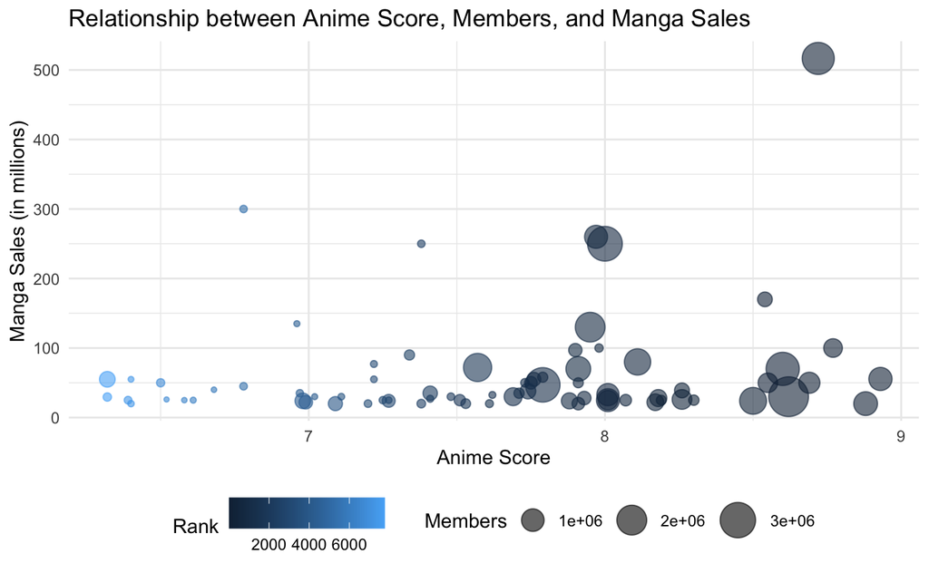

```r
# Load necessary packages for visualization
if (!require("ggplot2")) {
  install.packages("ggplot2")
}
library(ggplot2)

# Create a scatter plot with a trend line
ggplot(merged_data, aes(x = Score, y = `Approximate sales in million(s)`, size = Members, color = Rank)) +
  geom_point(alpha = 0.6) +
  scale_size_continuous(range = c(1, 10), name = "Members") +
  scale_color_continuous(name = "Rank") +
  labs(title = "Relationship between Anime Score, Members, and Manga Sales",
       x = "Anime Score",
       y = "Manga Sales (in millions)") +
  theme_minimal() +
  theme(legend.position = "bottom")
```

Description: This scatter plot visualizes the relationship between anime scores and manga sales, with the size of the points representing the number of members and the color indicating the rank of the anime. - X-axis (Anime Score): Represents the score of the anime. - Y-axis (Manga Sales): Represents the approximate sales of the manga series in millions. - Point Size (Members): Represents the number of members associated with each anime. - Point Color (Rank): Represents the rank of the anime.

Interpretation: - Correlation Analysis: The plot helps in visually assessing if there is a correlation between the anime score and manga sales. A trend line could indicate if higher-scored anime tend to have higher manga sales. - Popularity and Sales: By including the number of members, we can also infer if more popular anime (with more members) correlate with higher manga sales. - Rank Insights: The color gradient by rank can provide additional insights into how rank affects both score and sales.

Helpfulness: This graph is helpful in answering the research question as it brings together multiple variables (score, sales, members, and rank) to provide a comprehensive view of the data.

Modifications for Final Report: - Adding a Trend Line: Including a trend line to better visualize the correlation. - Annotations: Adding annotations or labels to highlight significant data points.

#### Plot 2

Include R code to make one data visualization (I would encourage you to use 3 or more variables). Include a brief written description of what your graph shows. Is this graph helpful in answering your research question? If it is helpful, will you need to add/modify anything in this graph in the final report?

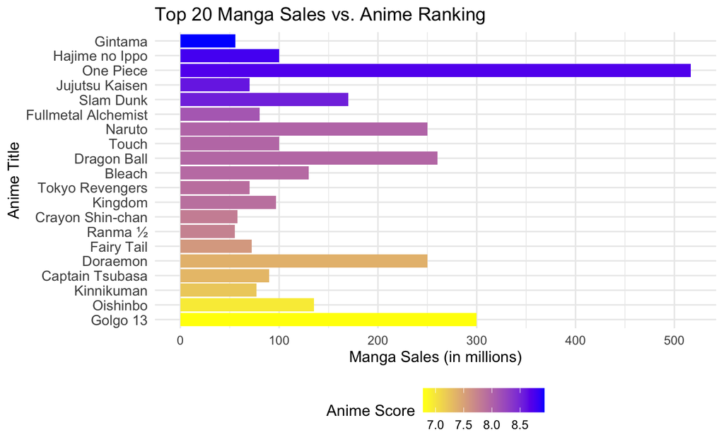

```r
# Load necessary packages for visualization
library(ggplot2)

# Select the top 20 manga by sales
top_20_manga <- merged_data %>%
  arrange(desc(`Approximate sales in million(s)`)) %>%
  head(20)

# Create a bar plot to show the relationship between manga sales and anime ranking
plot <- ggplot(top_20_manga, aes(x = reorder(Title, -Rank), y = `Approximate sales in million(s)`, fill = Score)) +
  geom_bar(stat = "identity") +
  coord_flip() +
  scale_fill_gradient(low = "yellow", high = "blue", name = "Anime Score") +
  labs(title = "Top 20 Manga Sales vs. Anime Ranking",
       x = "Anime Title",
       y = "Manga Sales (in millions)") +
  theme_minimal() +
  theme(legend.position = "bottom",
        axis.text.y = element_text(size = 10))

# Print the plot
print(plot)
```

```r
NA
NA
```

Helpfulness: This graph is directly related to the research question as it visually represents the relationship between the popularity of manga and the ranking of their anime adaptations.

Modifications for Final Report: Highlighting Significant Titles: Highlighting or annotating specific titles that are outliers or particularly significant.

## Conclusion

The analysis suggests that while there is some correlation between the popularity of manga and the ranking of their anime adaptations, it is not a definitive predictor. High manga sales do not always guarantee a high-ranking anime adaptation. Other factors, such as production quality, fidelity to the source material, and audience reception, significantly influence the success of an anime.

### Initial Intuition

Initially, it was hypothesized that there would be a significant correlation between the popularity of manga (measured by sales) and the ranking of their anime adaptations. The reasoning behind this intuition was that a popular manga would likely attract a larger audience, leading to higher anticipation and viewership for its anime adaptation, thus resulting in higher rankings.

### Data Analysis and Visualization

The data analysis involved merging two datasets: top anime ranked and best-selling manga. The merged dataset allowed us to visualize the relationship between manga sales, anime scores, and rankings. The key visualization, a bar plot, showed the relationship between the top 20 manga sales and their corresponding anime rankings.

### Key Findings

- Correlation Between Manga Sales and Anime Rankings: The visualizations provided insights into the relationship between manga sales and anime rankings. While some popular manga (e.g., “One Piece,” “Dragon Ball”) had high sales and their anime adaptations ranked well, this trend was not consistent across all titles.
- Variability in Anime Scores: The anime scores varied significantly even among highly popular manga, indicating that factors other than manga popularity, such as production quality, storyline adaptation, and audience reception, play a crucial role in determining the anime’s success.
- Top Manga Adaptations: Titles like “One Piece” and “Dragon Ball,” which had high manga sales, also showed good performance in their anime adaptations, supporting the initial intuition to some extent.

### Future Consideration

- Detailed Genre Analysis: Examining if certain genres show a stronger correlation between manga popularity and anime success.
- Production Factors: Investigating the impact of production studios, directors, and voice actors on the anime’s success.
- Audience Demographics: Analyzing how different audience demographics (age, region) influence the reception of anime adaptations.